# Face Analysis Technology Evaluation (FATE) Quality

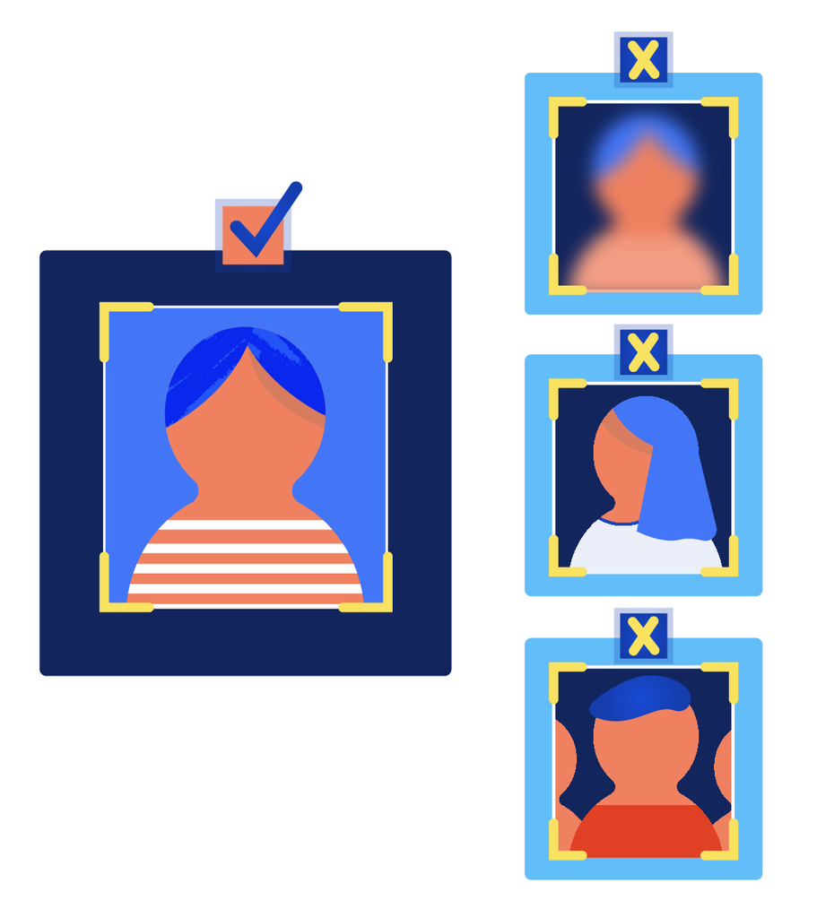

Credit: Natasha Hanacek/NIST

**Quality Specific Image Defect Detection (SIDD):** [Report](https://pages.nist.gov/frvt/reports/quality_sidd/frvt_quality_sidd_report.pdf) | [API and Concept Document](https://pages.nist.gov/frvt/api/FRVT_ongoing_quality_sidd_api.pdf) | [Validation](https://github.com/usnistgov/frvt) | [Encryption](https://www.nist.gov/itl/iad/image-group/products-and-services/encrypting-softwaredata-transmission-nist) | [Submit](https://pages.nist.gov/frvt/html/frvt_submission_form.html)  
**Quality Summarization:** [Draft Report](https://pages.nist.gov/frvt/reports/quality/frvt_quality_report.pdf) | [Participation Agreement](https://pages.nist.gov/frvt/agreements/frvt_participation_agreement.pdf) | [Concept Document](https://www.nist.gov/document/frvtqualityconcept10pdf) | [API](https://pages.nist.gov/frvt/api/FRVT_ongoing_quality_api.pdf)  
**Developers should wait *two* months after their last successful submission to submit a new submission.**

**[2025-09-14]** A new version of the [FATE SIDD Report](https://pages.nist.gov/frvt/reports/quality_sidd/frvt_quality_sidd_report.pdf) is now available. It includes new results for Secuveri.

**[2025-09-03]** A new version of the [FATE SIDD Report](https://pages.nist.gov/frvt/reports/quality_sidd/frvt_quality_sidd_report.pdf) is now available. It includes new results for Veridium.

**[2025-08-03]** A new version of the [FATE SIDD Report](https://pages.nist.gov/frvt/reports/quality_sidd/frvt_quality_sidd_report.pdf) is now available. It includes new results for Secuveri and Vsoft. Many figures and tables have been updated to span multiple pages to afford better readability. The webpage has been updated and now includes a table on pose estimation.

**[2025-06-30]** A new version of the [FATE SIDD Report](https://pages.nist.gov/frvt/reports/quality_sidd/frvt_quality_sidd_report.pdf) is now available. It includes new results for Dermalog.

**[2025-05-18]** A new version of the [FATE SIDD Report](https://pages.nist.gov/frvt/reports/quality_sidd/frvt_quality_sidd_report.pdf) is now available. It includes results for Secunet, Veridium, Vsoft, and Igd. It includes a new set for distributions of unified quality score on high quality images, for images exhibiting only minor departures from ISO/IEC 39794-5 Annex D photographic guidance.

**[2025-04-03]** A new version of the [FATE SIDD Report](https://pages.nist.gov/frvt/reports/quality_sidd/frvt_quality_sidd_report.pdf) is now available. It includes new results for Viante.

**[2025-03-02]** A new version of the [FATE SIDD Report](https://pages.nist.gov/frvt/reports/quality_sidd/frvt_quality_sidd_report.pdf) is now available. It includes new results for Secunet.

**[2025-01-23]** A new version of the [FATE SIDD Report](https://pages.nist.gov/frvt/reports/quality_sidd/frvt_quality_sidd_report.pdf) is now available. It includes new results for Secunet, Viante, and Cmcati.

**[2025-12-08]** A new version of the [FATE SIDD Report](https://pages.nist.gov/frvt/reports/quality_sidd/frvt_quality_sidd_report.pdf) is now available. It includes new results for Secunet, Ofiq1, and Veridium.

**[2025-08-07]** A new version of the [FATE SIDD Report](https://pages.nist.gov/frvt/reports/quality_sidd/frvt_quality_sidd_report.pdf) is now available. It includes new results for Daon, Innovatrics, and Pixelall.

**[2025-06-17]** A new version of the [FATE SIDD Report](https://pages.nist.gov/frvt/reports/quality_sidd/frvt_quality_sidd_report.pdf) is now available. It includes a new set for Distance from Eyes to Edges containing images with varying pose and background uniformity in which one eye is very close to the edge of the image, or partially out of the frame.

**[2025-05-22]** A new version of the [FATE SIDD Report](https://pages.nist.gov/frvt/reports/quality_sidd/frvt_quality_sidd_report.pdf) is now available. It includes new results for Mobbeel and Veridium and introduces a Resolution set with blur from air turbulence, instead of synthetic blur. The new plot is in section 3.14.3.

**[2025-04-15]** A new version of the [FATE SIDD Report](https://pages.nist.gov/frvt/reports/quality_sidd/frvt_quality_sidd_report.pdf) is now available. It includes additional plots showing the dependence of the Resolution quality measure on relative blur, the width of Gaussian blur normalized by inter-eye distance.

**[2025-03-14]** A new version of the [FATE SIDD Report](https://pages.nist.gov/frvt/reports/quality_sidd/frvt_quality_sidd_report.pdf) is now available. It includes results for Pixelall.

**[2025-01-21]** A new version of the [FATE SIDD Report](https://pages.nist.gov/frvt/reports/quality_sidd/frvt_quality_sidd_report.pdf) is now available. It includes results for IGD, Veridium, Mobbeel, ROC, and Kasikorn Labs.

We have also added a Kiosk dataset to the leaderboard below.

**[2024-12-09]** A new version of the [FATE SIDD Report](https://pages.nist.gov/frvt/reports/quality_sidd/frvt_quality_sidd_report.pdf) is now available. It includes results for Viante.

**[2024-11-15]** A new version of the [FATE SIDD Report](https://pages.nist.gov/frvt/reports/quality_sidd/frvt_quality_sidd_report.pdf) is now available. It introduces cumulative distribution plots by region-of-birth and sex, as well as demographic analysis for Unified Quality Score.

**[2024-10-04]** A new version of the [FATE SIDD Report](https://pages.nist.gov/frvt/reports/quality_sidd/frvt_quality_sidd_report.pdf) is now available. It includes results for PAPIL11.

**[2024-09-06]** A new version of the [FATE SIDD Report](https://pages.nist.gov/frvt/reports/quality_sidd/frvt_quality_sidd_report.pdf) is now available. It includes results for Ediffiqal and IGD. We have also added summary tables for Eyes Open 2 and Mouth Open 2.

**[2024-08-08]** A new version of the [FATE SIDD Report](https://pages.nist.gov/frvt/reports/quality_sidd/frvt_quality_sidd_report.pdf) is now available. It includes results for Mobbeel and Veridium.

**[2024-07-03]** A new version of the [FATE SIDD Report](https://pages.nist.gov/frvt/reports/quality_sidd/frvt_quality_sidd_report.pdf) is now available. It includes results for neurotechnology, qazsmartvisionai, and idemia.

We have added a section on demographics to address two topics: thresholds on quality measures, and demographic variability in quality measures.

Previous versions of the SIDD report can be found on our [GitHub page](https://github.com/usnistgov/frvt/blob/nist-pages/reports/quality_sidd/frvt_quality_sidd_report.pdf).

**[2024-05-13]** A new version of the [FATE SIDD Report](https://pages.nist.gov/frvt/reports/quality_sidd/frvt_quality_sidd_report.pdf) is now available. It includes results for cu-face.

**[2024-04-26]** A new version of the [FATE SIDD Report](https://pages.nist.gov/frvt/reports/quality_sidd/frvt_quality_sidd_report.pdf) is now available. It includes results for two new submissions from FRP Kauai and Secunet.

The Quality Algorithm Performance leaderboard below has been updated with algorithms that implemented Unified Quality Score.

The [Fate SIDD API Concept Document](https://pages.nist.gov/frvt/api/FRVT_ongoing_quality_sidd_api.pdf) was updated on 4-23-2024 to be in accordance with ISO/IEC DIS 29794-5.

**[2024-04-16]** A new version of the [FATE SIDD Report](https://pages.nist.gov/frvt/reports/quality_sidd/frvt_quality_sidd_report.pdf) is now available. It includes results for two new submissions from IGD and ROC.

The Quality Algorithm Performance leaderboard below has been updated with algorithms that implemented Unified Quality Score.

Previous versions of the SIDD report can be found on our [GitHub page](https://github.com/usnistgov/frvt/blob/nist-pages/reports/quality_sidd/frvt_quality_sidd_report.pdf).

**[2024-04-05]** A new version of the [FATE SIDD API Concept Document](https://pages.nist.gov/frvt/api/FRVT_ongoing_quality_sidd_api.pdf) is now posted. It sets a four-month period between submissions on slide 4 and specifies that the sign convention for pose estimates on slide 10 is the same as that in ISO/IEC 39794-5.

Previous versions of the API Concept Document can be found on our [GitHub page](https://github.com/usnistgov/frvt/blob/nist-pages/api/FRVT_ongoing_quality_sidd_api.pdf).

**[2024-03-29]** A new version of the [FATE SIDD Report](https://pages.nist.gov/frvt/reports/quality_sidd/frvt_quality_sidd_report.pdf) is now available. It includes a correction to Pitch Set 2 results due to a systematic offset in the determination of ground truth for Pitch Set 2.

Previous versions of the SIDD report can be found on our [GitHub page](https://github.com/usnistgov/frvt/blob/nist-pages/reports/quality_sidd/frvt_quality_sidd_report.pdf).

**[2024-03-08]** A new version of the [FATE SIDD Report](https://pages.nist.gov/frvt/reports/quality_sidd/frvt_quality_sidd_report.pdf) is now available. It includes results for one new submission from Mobbeel.

The Quality Algorithm Performance leaderboard below has been updated with algorithms that implemented Quality SIDD Unified Quality Score.

**[2024-02-14]** A new version of the [FATE SIDD Report](https://pages.nist.gov/frvt/reports/quality_sidd/frvt_quality_sidd_report.pdf) is now available. It includes results for two new submissions from ROC and Viante.

Previous versions of the SIDD report can be found on our [GitHub page](https://github.com/usnistgov/frvt/blob/nist-pages/reports/quality_sidd/frvt_quality_sidd_report.pdf).

The Quality Algorithm Performance leaderboard below has been updated with algorithms that implemented Quality SIDD Unified Quality Score.

**[2024-02-02]** A new version of the [FATE SIDD Report](https://pages.nist.gov/frvt/reports/quality_sidd/frvt_quality_sidd_report.pdf) is now available. It includes results for a new submission from IGD.

Previous versions of the SIDD report can be found on our [GitHub page](https://github.com/usnistgov/frvt/blob/nist-pages/reports/quality_sidd/frvt_quality_sidd_report.pdf).

**[2023-12-29]** A new version of the [FATE SIDD Report](https://pages.nist.gov/frvt/reports/quality_sidd/frvt_quality_sidd_report.pdf) is now available. It includes results for two new submissions from Datech and Vsoft.

Previous versions of the SIDD report can be found on our [GitHub page](https://github.com/usnistgov/frvt/blob/nist-pages/reports/quality_sidd/frvt_quality_sidd_report.pdf).

**[2023-12-15]** A new version of the [FATE SIDD Report](https://pages.nist.gov/frvt/reports/quality_sidd/frvt_quality_sidd_report.pdf) is now available. It includes results for two new submissions from Seamfix and Neurotechnology. In addition, we have made a correction to the Unified Quality Score plot for Digidata, and introduced a set for inter-eye distance with non-zero yaw.

Previous versions of the SIDD report can be found on our [GitHub page](https://github.com/usnistgov/frvt/blob/nist-pages/reports/quality_sidd/frvt_quality_sidd_report.pdf).

**[2023-12-04]** A new version of the [FATE SIDD API Concept Document](https://pages.nist.gov/frvt/api/FRVT_ongoing_quality_sidd_api.pdf) is now posted. It includes updated numbering for the ISO/IEC 29794-5 quality checks on slides 30 and 33, and current participation instructions on slide 4.

Previous versions of the API Concept Document can be found on our [GitHub page](https://github.com/usnistgov/frvt/blob/nist-pages/api/FRVT_ongoing_quality_sidd_api.pdf).

**[2023-12-01]** A new version of the [FATE SIDD Report](https://pages.nist.gov/frvt/reports/quality_sidd/frvt_quality_sidd_report.pdf) is now available. It includes results for two new submissions from Secunet. The results for Eyes Open 2, Mouth Open 2, and Face Occlusion 2 measures are included. From this date forward, the Eyes Open, Mouth Open, and Face Occlusion measures are no longer being evaluated.

The quality leaderboard has been updated with algorithms that implemented Quality SIDD Unified Quality Score.

**[2023-11-16]** A new version of the [FATE SIDD API Concept Document](https://pages.nist.gov/frvt/api/FRVT_ongoing_quality_sidd_api.pdf) is now posted. We are planning to deprecate EyesOpen, MouthOpen, and FaceOcclusion and have introduced EyesOpen2, MouthOpen2, and FaceOcclusion2. The new measures are aligned with ISO/IEC 29794-5 CD3.

Developers may continue to implement EyesOpen, MouthOpen, and FaceOcclusion until November 30, 2023, after which those measures will no longer be evaluated. The new measures are now present in the API and can be implemented.

Previous versions of the API Concept Document can be found on our [GitHub page](https://github.com/usnistgov/frvt/blob/nist-pages/api/FRVT_ongoing_quality_sidd_api.pdf).

**[2023-11-06]** A new version of the [FATE SIDD Report](https://pages.nist.gov/frvt/reports/quality_sidd/frvt_quality_sidd_report.pdf) is now available. It includes results for new submissions from October 2023. We have also changed median absolute error to mean absolute error and introduced two sets for manually determined pitch and yaw.

The quality leaderboard has been updated with algorithms that implemented Quality SIDD Unified Quality Score.

**[2023-10-11]** We are transitioning to evaluating Quality Summarization through only the “UnifiedQualityScore” component of Quality SIDD. Going forward, developers seeking to have their Quality Summarization algorithm evaluated should implement the Unified Quality Score component and [submit](https://pages.nist.gov/frvt/html/frvt_submission_form.html) to the Quality SIDD evaluation. The quality leaderboard has been updated to merge the results from the original Quality Summarization track with those from the Quality SIDD evaluation of Unified Quality Score.

**[2023-09-20]** We have released [NISTIR 8485](https://doi.org/10.6028/NIST.IR.8485) - Face Analysis Technology Evaluation (FATE) Part 11: Face Image Quality Vector Assessment: Specific Image Defect Detection. As described in [this press release](https://www.nist.gov/news-events/news/2023/09/whats-wrong-picture-nist-face-analysis-program-helps-find-answers), the report summarizes accuracy for seven submissions from five unique developers. We evaluated algorithms across 20 quality measures.  
This report will be discussed at the November 2023 Face Image Quality [Workshop](https://eab.org/events/program/325).

**[2023-08-18]** A revision of the API and concept document for the Specific Image Defect Detection track has been posted [here](https://pages.nist.gov/frvt/api/FRVT_ongoing_quality_sidd_api.pdf).  
We have updated references to FRVT to Face Analysis Technology Evaluation (FATE) and Face Recognition Technology Evaluation (FRTE).  
Previous versions of the API document can be found on the [GitHub page](https://github.com/usnistgov/frvt/blob/nist-pages/api/FRVT_ongoing_quality_sidd_api.pdf).

**[2023-08-09]** A revision of the API and concept document for the Specific Image Defect Detection track has been posted [here](https://pages.nist.gov/frvt/api/FRVT_ongoing_quality_sidd_api.pdf).  
References to FRVT have been changed to FATE to reflect the use of face analysis, rather than face recognition.  
Previous versions of the API document can be found on the [GitHub page](https://github.com/usnistgov/frvt/blob/nist-pages/api/FRVT_ongoing_quality_sidd_api.pdf).

**[2023-07-03]** Starting today, all algorithms, participation agreements, and GPG keys should be submitted using the [Submission Form](https://pages.nist.gov/frvt/html/frvt_submission_form.html).

**Background:** Quality assessment algorithms (QAA) are evaluated on their ability to assign low quality scores to border crossing images that are variously of non-ideal pose, illumination and resolution. QAAs can make two kinds of error: false rejection – saying an image is poor when it is not, which drives costs; and false acceptance – saying an image is good when it is not, which drives future recognition errors. This approach of requiring image quality to predict recognition failure has been the basis for development of [NFIQ](https://www.nist.gov/services-resources/software/nfiq-2) for fingerprints, which uses machine learning to map measurements from images to recognition scores.

**Results:** [last updated: 2026-09-12]

###### Prediction of Recognition Errors Summary: Entry-to-Visa

### Performance for Entry-to-Visa

The table shows how effective QAAs are at predicting recognition failure for Entry images when they are compared to high quality visa-like application photos. We set a recognition threshold such that the false non-match rate (FNMR) from a set of 15 accurate FRTE verification algorithms is 1%. We then recompute the FNMR after discarding one and five percent of the lowest quality samples, as assessed by the listed algorithms. Ideally, discarding 1% of values would yield FNMR = 0, corresponding to perfect prediction. In practice, however, the QAA does not always assign low quality values to images involved in false non-matches.

| Quality Algorithm | Submission Date | FNMR after removal of 1% lowest quality Entry images. Initial FNMR = 0.01. Lower is better. | FNMR after removal of 5% lowest quality Entry images. Initial FNMR = 0.01. Lower is better. | Efficiency after removal of 1% lowest quality Entry images. Higher is better. | Efficiency after removal of 5% lowest quality Entry images. Higher is better. |
| --- | --- | --- | --- | --- | --- |
| dermalog_002 | 2023-10-19 | 0.0077(44) | 0.0059(50) | 23.10 | 8.17 |
| idemia_002 | 2023-10-16 | 0.0055(10) | 0.0036(16) | 44.81 | 12.83 |
| neurotechnology_002 | 2023-07-10 | 0.0088(52) | 0.0052(45) | 12.27 | 9.65 |
| neurotechnology_003 | 2023-08-10 | 0.0082(48) | 0.0048(37) | 17.81 | 10.32 |
| cmcati_000 | 2026-01-13 | 0.0061(21) | 0.0045(32) | 38.76 | 11.03 |
| daon_000 | 2025-08-05 | 0.0054(7) | 0.0030(2) | 46.41 | 14.01 |
| datech_000 | 2023-12-08 | 0.0059(17) | 0.0036(17) | 41.36 | 12.73 |
| dermalog_003 | 2026-06-25 | 0.0100(61) | 0.0039(24) | 0.04 | 12.10 |
| ediffiqal_000 | 2024-07-22 | 0.0088(53) | 0.0051(43) | 12.12 | 9.89 |
| frpkauai_001 | 2024-04-15 | 0.0059(18) | 0.0034(15) | 40.92 | 13.11 |

[output cut: 59 more lines]

###### Prediction of Recognition Errors Summary: Kiosk-to-Entry

### Performance for Kiosk-to-Entry

The table shows how effective QAAs are at predicting recognition failure for Kiosk images when they are compared to medium-quality airport arrival webcam (Entry) photos. The Kiosk set has a higher percentage of very low-quality images compared to the Entry set. We set a recognition threshold such that the false non-match rate (FNMR) from a set of 15 accurate FRTE verification algorithms is 1%. We then recompute the FNMR after discarding 20% percent of the lowest quality samples, as assessed by the listed algorithms. Ideally, discarding more than 1% of values would yield FNMR = 0, corresponding to perfect prediction. In practice, however, the QAA does not always assign low quality values to images involved in false non-matches. Note that ties between quality scores or similarity scores when computing FNMR are broken randomly.

| Quality Algorithm | Submission Date | FNMR after removal of 20% lowest quality Kiosk images. Initial FNMR = 0.01. Lower is better. | Efficiency after removal of 20% lowest quality Kiosk images. Higher is better. |
| --- | --- | --- | --- |
| dermalog_002 | 2023-10-19 | 0.0033(29) | 3.3 |
| idemia_002 | 2023-10-16 | 0.0020(23) | 4.0 |
| neurotechnology_002 | 2023-07-10 | 0.0022(26) | 3.9 |
| neurotechnology_003 | 2023-08-10 | 0.0019(20) | 4.0 |
| cmcati_000 | 2026-01-13 | 0.0018(14) | 4.1 |
| daon_000 | 2025-08-05 | 0.0019(21) | 4.0 |
| datech_000 | 2023-12-08 | 0.0019(17) | 4.1 |
| dermalog_003 | 2026-06-25 | 0.0081(40) | 1.0 |
| ediffiqal_000 | 2024-07-22 | 0.0017(4) | 4.1 |
| frpkauai_001 | 2024-04-15 | 0.0021(25) | 4.0 |

[output cut: 35 more lines]

### Performance for Pose Estimation

The table shows the Mean Absolute Error (MAE) of algorithms on their pose estimation, where error is computed as the difference between ground truth and reported value. For images for which the algorithm does not detect a face, the error is 45 degrees. Lower MAE is better. It contains results for 3 yaw sets, 3 pitch sets, and 1 roll set.

**Yaw Sets**

For Yaw Set 1, at the time of capture, a camera is placed to the right or left of the subject at varying angles, with the subject remaining frontal and stationary. Yaw is recorded at the time of collection.

For Yaw Set 2, at the time of capture, the subject turns the head to look at a target to the left or right. Yaw is recorded at the time of collection.

For Yaw Set 3, a camera is placed to the right or left of the subject at varying angles; the subject remains stationary and frontal. Ground truth yaw values are determined by rotating a computer-generated model of a head to match the subject’s pose, and taking the corresponding yaw reading.

**Pitch Sets**

In Pitch Set 1, the subject generally has a neutral position and is standing against a mostly uniform background, with some shadows behind the subject. At the time of capture, a camera is placed at varying heights; the subject is asked to be frontal. Pitch is recorded at the time of collection.

In Pitch Set 2, the subject is seated and is against a uniform background. At the time of capture, a camera is placed at varying heights; the subject is asked to be frontal. Pitch is recorded at the time of collection.

In Pitch Set 3, the subject raises or lowers the head to look at targets at varying heights. Ground truth pitch values are determined by rotating a computer-generated model of a head to match the subject’s pose, and taking the corresponding pitch reading.

**Roll Set**

For Roll Set 1, images are mugshots that are rotated by a roll angle ranging from −30 to 30 degrees. In particular, we do not include images with a roll angle of 90 degrees. Rotation towards the subject’s right shoulder corresponds to a positive roll angle. Rotation towards the subject’s left shoulder corresponds to a negative roll angle. This sign convention is consistent with the ISO/IEC 39794-5:2019 standard.

| Quality Algorithm | Submission Date | Yaw Set 1 | Yaw Set 2 | Yaw Set 3 | Pitch Set 1 | Pitch Set 2 | Pitch Set 3 | Roll Set 1 |
| --- | --- | --- | --- | --- | --- | --- | --- | --- |
| roc_008 | 2024-12-23 | 4.99(1) | 9.59(1) | 5.07(40) | 9.72(34) | 8.47(21) | 8.01(43) | 1.50(29) |
| secuveri_002 | 2026-09-04 | 6.08(2) | 11.01(5) | 4.18(25) | 5.62(3) | 15.94(52) | 4.90(20) | 1.40(18) |
| viante_001 | 2024-12-02 | 6.27(3) | 11.27(9) | 4.51(38) | 7.01(21) | 7.54(9) | 4.69(6) | 1.29(9) |
| viante_003 | 2026-03-27 | 6.27(4) | 11.27(8) | 4.51(36) | 7.01(19) | 7.54(10) | 4.69(4) | 1.29(10) |
| viante_002 | 2025-12-30 | 6.27(5) | 11.27(11) | 4.51(37) | 7.01(20) | 7.54(11) | 4.69(5) | 1.29(11) |
| viante_000 | 2024-02-06 | 6.28(6) | 11.27(10) | 4.51(39) | 7.01(22) | 7.54(12) | 4.71(7) | 1.29(12) |
| secunet_006 | 2025-10-20 | 6.48(7) | 11.14(6) | 3.98(22) | 5.81(5) | 14.39(50) | 4.87(18) | 1.35(15) |
| secunet_008 | 2026-02-20 | 6.69(8) | 11.29(13) | 3.66(17) | 5.60(2) | 13.80(47) | 4.84(15) | 1.30(14) |
| roc_006 | 2024-02-05 | 6.75(9) | 10.75(2) | 5.47(43) | 10.60(37) | 13.14(42) | 9.51(46) | 1.37(16) |
| roc_007 | 2024-04-05 | 6.75(10) | 10.75(3) | 5.47(44) | 10.60(38) | 13.14(43) | 9.51(47) | 1.37(17) |

[output cut: 45 more lines]

The figures below show a more complete view of the Entry-to-Visa tab above: They show FNMR gains as a function of the fraction of lowest quality images discarded, and also considers four initial FNMR values: 0.5%, 1%, 2%, and 5%. It is evident that the algorithms are more effective when detecting the least recognizable images i.e. when the initial FNMR is set to 0.5%. If, instead, we ask the algorithms to detect the worst 5% of images, the relative FNMR gains are reduced.

Ground truth for quality is set as the false negatives from 15 of the more accurate recognition algorithms, one per developer. Mate scores are from comparison of high quality visa-like application photos with medium quality airport arrival webcam photos. Quality is computed only on the webcam photos.The dotted line gives either half the initial FNMR, or the lowest observed value. A steeply declining curve connotes a better QA.

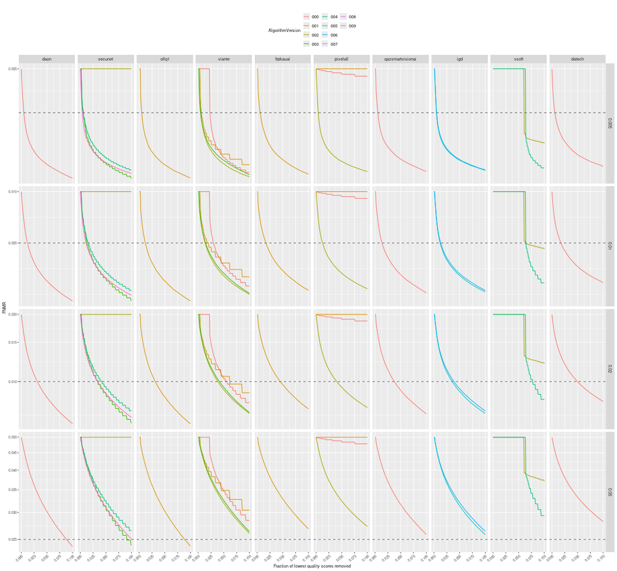

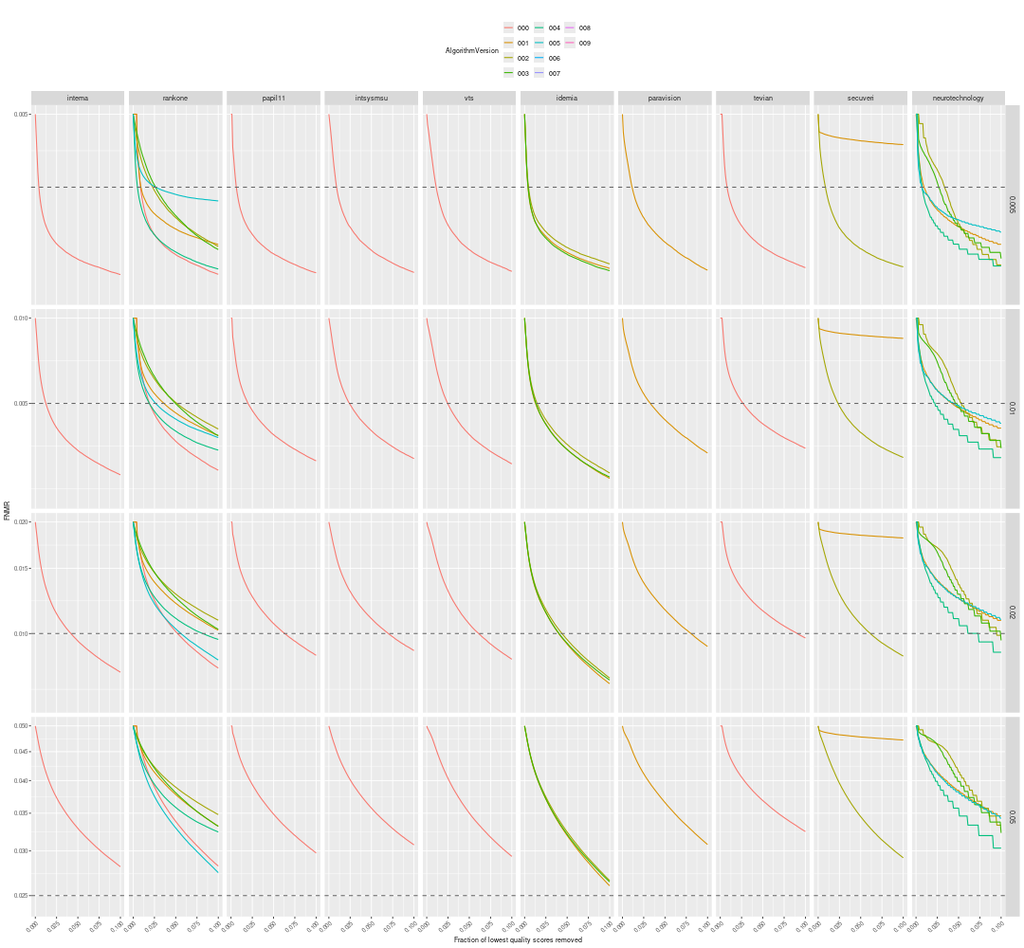

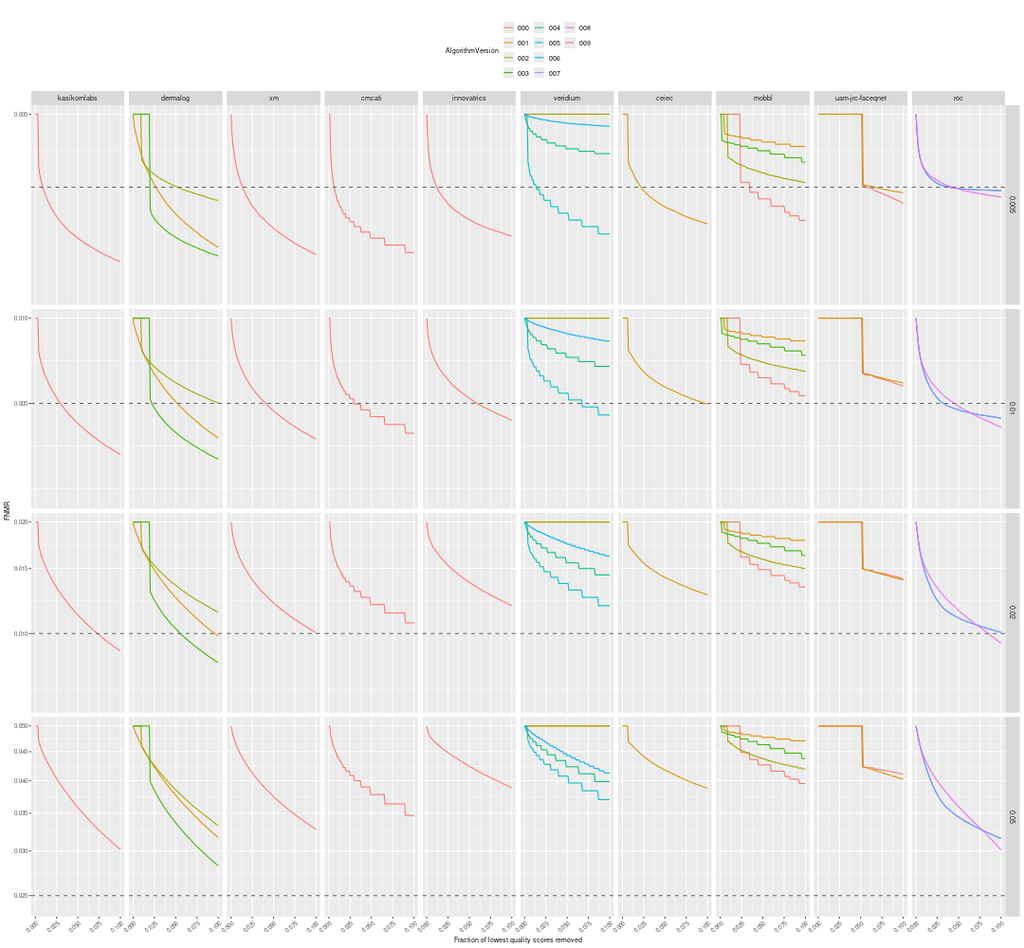

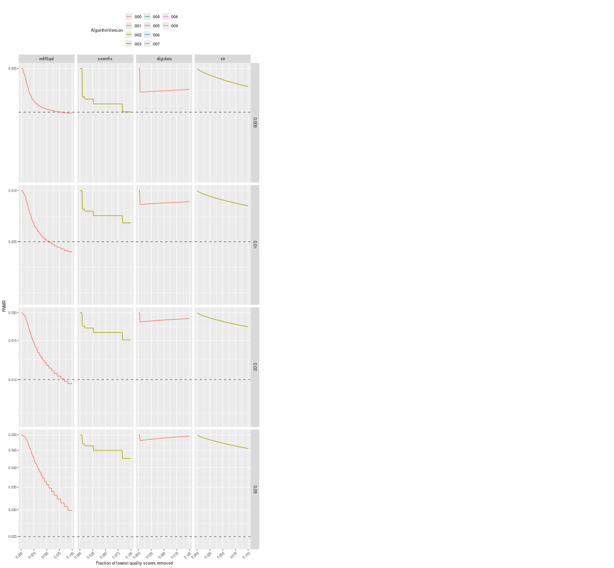

Face recognition accuracy has improved markedly due to development of new recognition algorithms and approaches. Nevertheless, recognition error rates remain significantly above zero, particularly in applications where photography of faces is difficult or when stringent thresholds must be applied to recognition outcomes to reduce false positives. For those applications that retain an image as an authoritative reference sample against which future recognitions are done, it is critical to maintain database quality. To that end, quality assessment tools are applicable:

- **Quality scalar**: An image is converted into a quality value. Low values might be used to trigger collection of a new image, or to switch to an alternative modality. Quality scalars are useful also as a survey statistic. When computed over a large collection, quality statistics can reveal diurnal, seasonal variations, trends, or collection site variability for example.
- **Quality vector**: An image is analyzed and properties related to face recognition failure are reported. These quantify imaging-related properties such as focus, illumination, distortion, and noise, and also subject-related properties like head-pose, facial expression, and eyeglasses effects. Such tools are useful for providing actionable feedback to a user, or photographer.

The defining properties of a face quality scalar are described in the Quality Concept Document linked above. The document targets the ISO/IEC/ICAO specifications of a full frontal face as the reference against which quality must be assessed.

ISO/IEC JTC 1 SC37, the committee for standardization in biometrics, has two projects related to improving face image quality assessment: - **ISO/IEC 29794-5**: definitions of tests for a face image quality vector - **ISO/IEC 24358**: specifications for face-aware capture subsystems [Status: Working draft]

To participate in this evaluation, developers need to submit a participation agreement to NIST, wrap their software behind the published C++ API, run their libraries through the provided validation package (which creates a submission package), encrypt the package, and provide a download link for the encrypted submission package. More details are provided below.

### Participation Agreement

FATE is conducted by NIST, an agency of the United States Government. Participation is free of charge. FATE is open to a global audience of face recognition developers. All organizations who seek to participate in FATE must sign all pages of this [Participation Agreement](https://pages.nist.gov/frvt/agreements/frvt_participation_agreement.pdf) and submit it with their algorithm submission using the [FRTE Submission Form](https://pages.nist.gov/frvt/html/frvt_submission_form.html). [last update: 2023-07-03]

[NOTE:] Organizations that have already submitted a participation agreement for FRTE Ongoing 1:1 do not need to send in a new participation agreement UNLESS the organization updates their cryptographic signing key.

### API Document

A definitive [API document](https://pages.nist.gov/frvt/api/FRVT_ongoing_quality_api.pdf) has been published. All FATE APIs reference the supporting [FRTE/FATE General Evaluation Specifications](https://pages.nist.gov/frvt/api/FRVT_common.pdf), which includes hardware and operating system environment, software requirements, reporting, and common data structures that support the APIs. All algorithms submitted must adhere to the published C++ API. [last update: 2023-04-06]

### Validation

A [validation package](https://github.com/usnistgov/frvt) has been published. All participants must run their software through the updated validation package prior to submission. The purpose of validation is to ensure consistent algorithm output between your execution and NIST’s execution. [last update: 2023-04-28]

### Encryption

All submissions must be properly encrypted and signed before transmission to NIST. This must be done according to these [instructions](https://www.nist.gov/system/files/documents/2021/10/25/nist_encryption.pdf) using the FRTE/FATE Ongoing public key linked from this [page](https://www.nist.gov/itl/iad/image-group/products-and-services/encrypting-softwaredata-transmission-nist). Participants must email their public key to NIST. The participant’s public key must correspond to the participant’s public-key fingerprint provided on the signed Participation Application. [last update: 2019-04-23]

### Submission

All algorithm submissions must be submitted through the [Submission Form](https://pages.nist.gov/frvt/html/frvt_submission_form.html), which requires encrypted files be provided as a download link from a generic http server (e.g., Google Drive). We cannot accept Dropbox links. NIST will not register, or establish any kind of membership, on the provided website. Participants can submit their algorithm(s), participation agreement, and GPG key at the same time via the submission form. [last update: 2023-07-03]

Participants must subscribe to the FRVT mailing list to receive emails when new reports are published or announcements are made.

Inquiries and comments may be submitted to frvt@nist.gov.

Subscribe to the FRVT mailing list to receive emails when announcements or updates are made.

## Related NIST Projects

##### [Ongoing Face Evaluations](https://www.nist.gov/programs-projects/face-recognition-vendor-test-frvt-ongoing)

## FRTE Projects

##### [FRTE 1:1 Verification](https://pages.nist.gov/frvt/html/frvt11.html)

##### [FRTE 1:N Identification](https://pages.nist.gov/frvt/html/frvt1N.html)

##### [FRTE Demographic Effects](https://pages.nist.gov/frvt/html/frvt_demographics.html)

##### [FRTE Face Mask Effects](https://pages.nist.gov/frvt/html/frvt_facemask.html)

##### [FRTE Paperless Travel](https://pages.nist.gov/frvt/html/frvt_paperless_travel.html)

##### [FRTE Twins Demonstration](https://pages.nist.gov/frvt/html/frvt_twins_demonstration.html)

##### [FRTE FIVE](https://pages.nist.gov/frvt/html/frte_five.html)

## FATE Projects

##### [FATE MORPH](https://pages.nist.gov/frvt/html/frvt_morph.html)

##### [FATE Quality](https://pages.nist.gov/frvt/html/frvt_quality.html)

##### [FATE PAD](https://pages.nist.gov/frvt/html/frvt_pad.html)

##### [FATE Age Estimation & Verification](https://pages.nist.gov/frvt/html/frvt_age_estimation.html)